# Cap 5: Transformación de datos

### Donde estamos?

[figure not shown]

### Previamente (Cap 4):

[figure not shown]

### Motivación:

- Los datos no siempre están dispuestos de la forma que necesitamos (por ejemplo para hacer una visualización)
- Necesidad de crear variables, resúmenes, cambiar nombre de variables o reordenar.

### Librerías y datos:

```r
library(tidyverse)
library(datos)
```

**Dataset:** vuelos

### Paquete dplyr

En este capítulo se habla principalmente del uso de 6 funciones (asociadas a verbos) de este paquete. Las 5 primeras pueden usarse junto a la sexta.

1. `filter()`
2. `arrange()`
3. `select()`
4. `mutate()`
5. `summarise()`
6. `group_by()`

Estas funciones no modifican el input, es decir, hay que agregar a un objeto si queremos guardar el resultado.

Todas las funciones siguen una misma estructura:

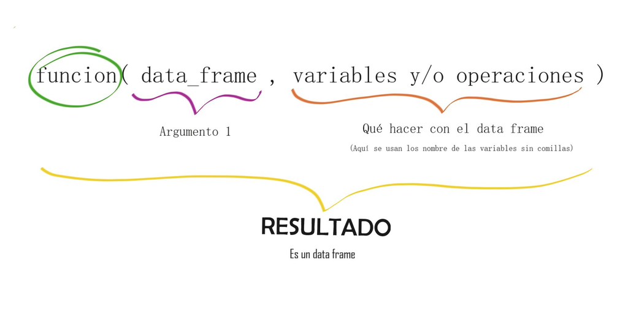

1. `filter()`

Selecciona filas que cumplen condiciones: `filter(data_frame, condiciones)`

**Importante:**

- Para las condiciones usamos: `> , >=, <, <=, != (diferente), == (igual)`
- función `near()` más confiable que `==`.
- Todas las condiones que se pongan (separadas por comas) se entienden como un &. Eso nos lleva a recordar los *operadores lógicos*.
  - & (y)
  - (o)
  - ! (no)
- También se ´puede usar `%in%` para considerar varias valores de una variable.
- Cuando realizamos un filtro se descartan los NA. (pero se puede agregar como una condición adicional)
2. `arrange()`

Nos sirva para ordenar (no selecciona sino que ordena): `arrange(data_frame, variable/s que se usa/n para ordenar)`

**Importante**:

- Ordena de forma ascendente, para descentende usar `desc()`.
- Los NA en la ordenación se colocan al final.
3. `select()`

Selecciona columnas (variables): `select(data_frame, variables a seleccionar(separadas por comas))`

**Importante**:

- Hay varias opciones adicionales que s epueden usar dentro de `select()`:
  - `var1:var2` (todas entre var1 y var2 incluyéndolas)
  - `-(var:var2)` todas excepto las que están entre var1 y var2 (incluyéndolas)
  - `start_with("abc")`
  - `ends_with("xyz")`
  - `contains("ijk")`
  - `matches ("(.)\\1")` variables con caracteres repetidos.
  - `num_range("x",1:3)` coincide con x1, x2, x3
- Si bien se puede usar para cambiar nombres de variables se uede usar `rename()`. Esta última no elimina las variables que no se nombran.
- Mover un grupo de variables al inicio con: `select(data_frame, varX, everything())` (pone a la varX en el inicio, la elimina de su posición original y luego coloca las demás).
4. `mutate()`

Agrega columnas (creadas) al final: `mutate(data_frame, var_ nueva = var1 / var2 )`

**Importante**:

- Se puede hacer referencia a variables recién creadas.
- Para guardar en un nuevo data frame SOLO las variables recien creadas se puede usar `transmute()`
- En `mutate()` se pueden usar: operadores aritméticos, aritmética modular, logaritmos, rezagos, agregados acumulativos, comparaciones lógicas, ordenamientos.
5. `summarise()`

Permite hacer resúmenes: `summarise(data_frame, promedioVar1 = mean(Var1, na.rm=TRUE))`

**Importante:**

Se puede aprovechar mejor si se usa con `group_by()`.

6. `group_by()`

Esta función cambia la unidad de análisis de los datos completos a grupos individuales. Al aplicar los **verbos** dplyr éstos se aplicarán por grupos.

```r
por_dia <- group_by(vuelos, anio, mes, dia) #cambia unidad de análisis
summarise(por_dia, atraso = mean(atraso_salida, na.rm = TRUE)) #al aplicar summarise lo hace en cada grupo.
```

```
## # A tibble: 365 x 4
## # Groups:   anio, mes [12]
##     anio   mes   dia atraso
##    <int> <int> <int>  <dbl>
##  1  2013     1     1  11.5
##  2  2013     1     2  13.9
##  3  2013     1     3  11.0
##  4  2013     1     4   8.95
##  5  2013     1     5   5.73
##  6  2013     1     6   7.15
##  7  2013     1     7   5.42
##  8  2013     1     8   2.55
##  9  2013     1     9   2.28
## 10  2013     1    10   2.84
## # ... with 355 more rows
```

### Ejercicios

```r
#Filter
filter(vuelos, mes == 1, dia == 1)
```

```
## # A tibble: 842 x 19
##     anio   mes   dia horario_salida salida_programa~ atraso_salida
##    <int> <int> <int>          <int>            <int>         <dbl>
##  1  2013     1     1            517              515             2
##  2  2013     1     1            533              529             4
##  3  2013     1     1            542              540             2
##  4  2013     1     1            544              545            -1
##  5  2013     1     1            554              600            -6
##  6  2013     1     1            554              558            -4
##  7  2013     1     1            555              600            -5
##  8  2013     1     1            557              600            -3
##  9  2013     1     1            557              600            -3
## 10  2013     1     1            558              600            -2
## # ... with 832 more rows, and 13 more variables: horario_llegada <int>,
## #   llegada_programada <int>, atraso_llegada <dbl>, aerolinea <chr>,
## #   vuelo <int>, codigo_cola <chr>, origen <chr>, destino <chr>,
## #   tiempo_vuelo <dbl>, distancia <dbl>, hora <dbl>, minuto <dbl>,
## #   fecha_hora <dttm>
```

```r
#Dos formas de hacer lo mismo:
filter(vuelos, mes == 11 | mes == 12)
```

```
## # A tibble: 55,403 x 19
##     anio   mes   dia horario_salida salida_programa~ atraso_salida
##    <int> <int> <int>          <int>            <int>         <dbl>
##  1  2013    11     1              5             2359             6
##  2  2013    11     1             35             2250           105
##  3  2013    11     1            455              500            -5
##  4  2013    11     1            539              545            -6
##  5  2013    11     1            542              545            -3
##  6  2013    11     1            549              600           -11
##  7  2013    11     1            550              600           -10
##  8  2013    11     1            554              600            -6
##  9  2013    11     1            554              600            -6
## 10  2013    11     1            554              600            -6
## # ... with 55,393 more rows, and 13 more variables: horario_llegada <int>,
## #   llegada_programada <int>, atraso_llegada <dbl>, aerolinea <chr>,
## #   vuelo <int>, codigo_cola <chr>, origen <chr>, destino <chr>,
## #   tiempo_vuelo <dbl>, distancia <dbl>, hora <dbl>, minuto <dbl>,
## #   fecha_hora <dttm>
```

```r
(nov_dic <- filter(vuelos, mes %in% c(11, 12)))
```

```
## # A tibble: 55,403 x 19
##     anio   mes   dia horario_salida salida_programa~ atraso_salida
##    <int> <int> <int>          <int>            <int>         <dbl>
##  1  2013    11     1              5             2359             6
##  2  2013    11     1             35             2250           105
##  3  2013    11     1            455              500            -5
##  4  2013    11     1            539              545            -6
##  5  2013    11     1            542              545            -3
##  6  2013    11     1            549              600           -11
##  7  2013    11     1            550              600           -10
##  8  2013    11     1            554              600            -6
##  9  2013    11     1            554              600            -6
## 10  2013    11     1            554              600            -6
## # ... with 55,393 more rows, and 13 more variables: horario_llegada <int>,
## #   llegada_programada <int>, atraso_llegada <dbl>, aerolinea <chr>,
## #   vuelo <int>, codigo_cola <chr>, origen <chr>, destino <chr>,
## #   tiempo_vuelo <dbl>, distancia <dbl>, hora <dbl>, minuto <dbl>,
## #   fecha_hora <dttm>
```

```r
#NA
df <- tibble(x = c(1, NA, 3))
filter(df, x > 1)
```

```
## # A tibble: 1 x 1
##       x
##   <dbl>
## 1     3
```

```r
filter(df, is.na(x) | x > 1)
```

```
## # A tibble: 2 x 1
##       x
##   <dbl>
## 1    NA
## 2     3
```

```r
#Arrange
arrange(vuelos, anio, mes, dia)
```

```
## # A tibble: 336,776 x 19
##     anio   mes   dia horario_salida salida_programa~ atraso_salida
##    <int> <int> <int>          <int>            <int>         <dbl>
##  1  2013     1     1            517              515             2
##  2  2013     1     1            533              529             4
##  3  2013     1     1            542              540             2
##  4  2013     1     1            544              545            -1
##  5  2013     1     1            554              600            -6
##  6  2013     1     1            554              558            -4
##  7  2013     1     1            555              600            -5
##  8  2013     1     1            557              600            -3
##  9  2013     1     1            557              600            -3
## 10  2013     1     1            558              600            -2
## # ... with 336,766 more rows, and 13 more variables: horario_llegada <int>,
## #   llegada_programada <int>, atraso_llegada <dbl>, aerolinea <chr>,
## #   vuelo <int>, codigo_cola <chr>, origen <chr>, destino <chr>,
## #   tiempo_vuelo <dbl>, distancia <dbl>, hora <dbl>, minuto <dbl>,
## #   fecha_hora <dttm>
```

```r
arrange(vuelos, desc(atraso_salida))
```

```
## # A tibble: 336,776 x 19
##     anio   mes   dia horario_salida salida_programa~ atraso_salida
##    <int> <int> <int>          <int>            <int>         <dbl>
##  1  2013     1     9            641              900          1301
##  2  2013     6    15           1432             1935          1137
##  3  2013     1    10           1121             1635          1126
##  4  2013     9    20           1139             1845          1014
##  5  2013     7    22            845             1600          1005
##  6  2013     4    10           1100             1900           960
##  7  2013     3    17           2321              810           911
##  8  2013     6    27            959             1900           899
##  9  2013     7    22           2257              759           898
## 10  2013    12     5            756             1700           896
## # ... with 336,766 more rows, and 13 more variables: horario_llegada <int>,
## #   llegada_programada <int>, atraso_llegada <dbl>, aerolinea <chr>,
## #   vuelo <int>, codigo_cola <chr>, origen <chr>, destino <chr>,
## #   tiempo_vuelo <dbl>, distancia <dbl>, hora <dbl>, minuto <dbl>,
## #   fecha_hora <dttm>
```

```r
#Select
select(vuelos, anio, mes, dia)
```

```
## # A tibble: 336,776 x 3
##     anio   mes   dia
##    <int> <int> <int>
##  1  2013     1     1
##  2  2013     1     1
##  3  2013     1     1
##  4  2013     1     1
##  5  2013     1     1
##  6  2013     1     1
##  7  2013     1     1
##  8  2013     1     1
##  9  2013     1     1
## 10  2013     1     1
## # ... with 336,766 more rows
```

```r
select(vuelos, -(anio:dia))
```

```
## # A tibble: 336,776 x 16
##    horario_salida salida_programa~ atraso_salida horario_llegada
##             <int>            <int>         <dbl>           <int>
##  1            517              515             2             830
##  2            533              529             4             850
##  3            542              540             2             923
##  4            544              545            -1            1004
##  5            554              600            -6             812
##  6            554              558            -4             740
##  7            555              600            -5             913
##  8            557              600            -3             709
##  9            557              600            -3             838
## 10            558              600            -2             753
## # ... with 336,766 more rows, and 12 more variables: llegada_programada <int>,
## #   atraso_llegada <dbl>, aerolinea <chr>, vuelo <int>, codigo_cola <chr>,
## #   origen <chr>, destino <chr>, tiempo_vuelo <dbl>, distancia <dbl>,
## #   hora <dbl>, minuto <dbl>, fecha_hora <dttm>
```

```r
rename(vuelos, cola_num = codigo_cola)
```

```
## # A tibble: 336,776 x 19
##     anio   mes   dia horario_salida salida_programa~ atraso_salida
##    <int> <int> <int>          <int>            <int>         <dbl>
##  1  2013     1     1            517              515             2
##  2  2013     1     1            533              529             4
##  3  2013     1     1            542              540             2
##  4  2013     1     1            544              545            -1
##  5  2013     1     1            554              600            -6
##  6  2013     1     1            554              558            -4
##  7  2013     1     1            555              600            -5
##  8  2013     1     1            557              600            -3
##  9  2013     1     1            557              600            -3
## 10  2013     1     1            558              600            -2
## # ... with 336,766 more rows, and 13 more variables: horario_llegada <int>,
## #   llegada_programada <int>, atraso_llegada <dbl>, aerolinea <chr>,
## #   vuelo <int>, cola_num <chr>, origen <chr>, destino <chr>,
## #   tiempo_vuelo <dbl>, distancia <dbl>, hora <dbl>, minuto <dbl>,
## #   fecha_hora <dttm>
```

```r
select(vuelos, fecha_hora, tiempo_vuelo, everything())
```

```
## # A tibble: 336,776 x 19
##    fecha_hora          tiempo_vuelo  anio   mes   dia horario_salida
##    <dttm>                     <dbl> <int> <int> <int>          <int>
##  1 2013-01-01 05:00:00          227  2013     1     1            517
##  2 2013-01-01 05:00:00          227  2013     1     1            533
##  3 2013-01-01 05:00:00          160  2013     1     1            542
##  4 2013-01-01 05:00:00          183  2013     1     1            544
##  5 2013-01-01 06:00:00          116  2013     1     1            554
##  6 2013-01-01 05:00:00          150  2013     1     1            554
##  7 2013-01-01 06:00:00          158  2013     1     1            555
##  8 2013-01-01 06:00:00           53  2013     1     1            557
##  9 2013-01-01 06:00:00          140  2013     1     1            557
## 10 2013-01-01 06:00:00          138  2013     1     1            558
## # ... with 336,766 more rows, and 13 more variables: salida_programada <int>,
## #   atraso_salida <dbl>, horario_llegada <int>, llegada_programada <int>,
## #   atraso_llegada <dbl>, aerolinea <chr>, vuelo <int>, codigo_cola <chr>,
## #   origen <chr>, destino <chr>, distancia <dbl>, hora <dbl>, minuto <dbl>
```

```r
#Mutate
vuelos_sml <- select(vuelos,
  anio:dia,
  starts_with("atraso"),
  distancia,
  tiempo_vuelo
)
mutate(vuelos_sml,
  ganancia = atraso_salida - atraso_llegada,
  velocidad = distancia / tiempo_vuelo * 60
)
```

```
## # A tibble: 336,776 x 9
##     anio   mes   dia atraso_salida atraso_llegada distancia tiempo_vuelo
##    <int> <int> <int>         <dbl>          <dbl>     <dbl>        <dbl>
##  1  2013     1     1             2             11      1400          227
##  2  2013     1     1             4             20      1416          227
##  3  2013     1     1             2             33      1089          160
##  4  2013     1     1            -1            -18      1576          183
##  5  2013     1     1            -6            -25       762          116
##  6  2013     1     1            -4             12       719          150
##  7  2013     1     1            -5             19      1065          158
##  8  2013     1     1            -3            -14       229           53
##  9  2013     1     1            -3             -8       944          140
## 10  2013     1     1            -2              8       733          138
## # ... with 336,766 more rows, and 2 more variables: ganancia <dbl>,
## #   velocidad <dbl>
```

```r
#usar variables recien creada
mutate(vuelos_sml,
  ganancia = atraso_salida - atraso_llegada,
  horas = tiempo_vuelo / 60,
  ganacia_por_hora = ganancia / horas
)
```

```
## # A tibble: 336,776 x 10
##     anio   mes   dia atraso_salida atraso_llegada distancia tiempo_vuelo
##    <int> <int> <int>         <dbl>          <dbl>     <dbl>        <dbl>
##  1  2013     1     1             2             11      1400          227
##  2  2013     1     1             4             20      1416          227
##  3  2013     1     1             2             33      1089          160
##  4  2013     1     1            -1            -18      1576          183
##  5  2013     1     1            -6            -25       762          116
##  6  2013     1     1            -4             12       719          150
##  7  2013     1     1            -5             19      1065          158
##  8  2013     1     1            -3            -14       229           53
##  9  2013     1     1            -3             -8       944          140
## 10  2013     1     1            -2              8       733          138
## # ... with 336,766 more rows, and 3 more variables: ganancia <dbl>,
## #   horas <dbl>, ganacia_por_hora <dbl>
```

```r
#usar transmute
transmute(vuelos,
  ganancia = atraso_salida - atraso_llegada,
  horas = tiempo_vuelo / 60,
  ganancia_por_hora = ganancia / horas
)
```

```
## # A tibble: 336,776 x 3
##    ganancia horas ganancia_por_hora
##       <dbl> <dbl>             <dbl>
##  1       -9 3.78              -2.38
##  2      -16 3.78              -4.23
##  3      -31 2.67             -11.6
##  4       17 3.05               5.57
##  5       19 1.93               9.83
##  6      -16 2.5               -6.4
##  7      -24 2.63              -9.11
##  8       11 0.883             12.5
##  9        5 2.33               2.14
## 10      -10 2.3               -4.35
## # ... with 336,766 more rows
```

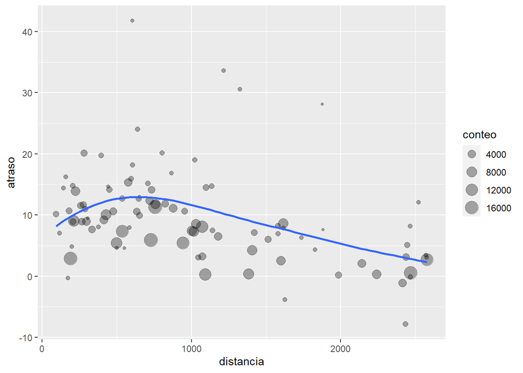

```r
#Summarise
por_destino <- group_by(vuelos, destino)
atraso <- summarise(por_destino,
  conteo = n(),
  distancia = mean(distancia, na.rm = TRUE),
  atraso = mean(atraso_llegada, na.rm = TRUE)
)
atraso <- filter(atraso, conteo > 20, destino != "HNL")
ggplot(data = atraso, mapping = aes(x = distancia, y = atraso)) +
  geom_point(aes(size = conteo), alpha = 1/3) +
  geom_smooth(se = FALSE)
```

```r
#Uso del pipe %>%
atrasos <- vuelos %>%
  group_by(destino) %>%
  summarise(
    conteo = n(),
    distancia = mean(distancia, na.rm = TRUE),
    atraso = mean(atraso_llegada, na.rm = TRUE)
  ) %>%
  filter(conteo > 20, destino != "HNL")
```

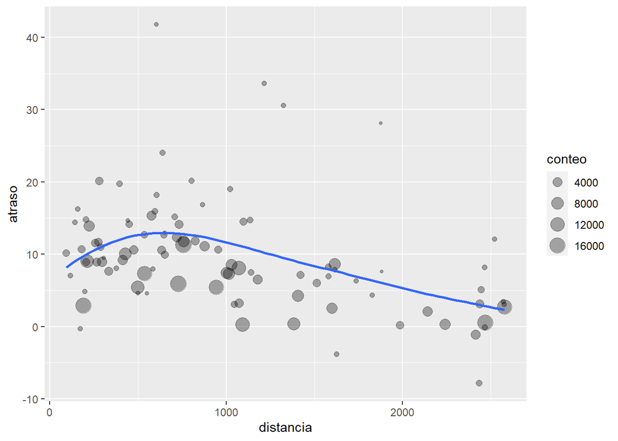

```r
# Uso del pipe + ggplot
vuelos %>%
  group_by(destino) %>%
  summarise(
    conteo = n(),
    distancia = mean(distancia, na.rm = TRUE),
    atraso = mean(atraso_llegada, na.rm = TRUE)
  ) %>%
  filter(conteo > 20, destino != "HNL") %>%
  ggplot(mapping = aes(x = distancia, y = atraso)) +
  geom_point(aes(size = conteo), alpha = 1 / 3) +
  geom_smooth(se = FALSE)
```